# Species Distribution Indicators

**Description**: Species mean depth, along-shelf distance, and distance to coastline

**Found in**: State of the Ecosystem - Gulf of Maine & Georges Bank (2017, 2018, 2019), State of the Ecosystem - Mid-Atlantic (2017, 2018, 2019)

**Indicator category**: Extensive analysis; not yet published

**Contributor(s)**: Kevin Friedland

**Data steward**: Kevin Friedland, kevin.friedland@noaa.gov

**Point of contact**: Kevin Friedland, kevin.friedland@noaa.gov

**Public availability statement**: Source data are available upon request (read more [here](https://inport.nmfs.noaa.gov/inport/item/22560)). Derived data may be downloaded [here](https://comet.nefsc.noaa.gov/erddap/tabledap/SOE_habitat_soe_v1.html).

## Methods

Three metrics quantifying spatial-temporal distribution shifts within fish populations were developed by @Friedland2018, including mean depth, along-shelf distance, and distance to coastline. Along-shelf distance is a metric for quantifying the distribution of a species through time along the axis of the US Northeast Continental Shelf, which extends northeastward from the Outer Banks of North Carolina. Values in the derived time series correspond to mean distance in km from the southwest origin of the along-shelf axis at 0 km. The along-shelf axis begins at 76.53°W 34.60°N and terminates at 65.71°W 43.49°N.

Once mean distance is found, depth of occurrence and distance to coastline can be calculated for each species’ positional center. Analyses present in the State of the Ecosystem (SOE) reports include mean depth and along-shelf distance for Atlantic cod, sea scallop, summer flounder, and black sea bass.

### Data sources

Data for these indicators were derived from fishery-independent bottom trawl survey data collected by the Northeast Fisheries Science Center (NEFSC).

### Data analysis

Species distribution indicators were derived using the following R code.

```r
library(raster)
library(ncdf4)
library(stats)
library(geosphere)
library(plyr)

# set wd C:\1_analyses_ne_shelf\along shelf pos
#setwd(choose.dir(default=getwd()))
setwd("C:/1_analyses_ne_shelf/along shelf pos")
wd=getwd()


# name of survey data file select season <<<<<<<<<<<<<<<<<<<<<<<<<<<<<<<<<<<<<<<<<
surfilename="Survdat_8_2017.Rdata"

# select season SPRING <<<<<<<<<<<<<<<<<<<<<<<<<<<<<<<<<<<<<<<<<<<<<<<<<<<<<<<<<<<
selseaon="SPRING"
outfile="dhdc_8_2017_fallASS_sprDATA.csv"
outfile="dhdc_8_2017_fallASS_sprDATA jc.csv"
outfile="dhdc_8_2017_fallASS_sprDATA joe.csv"
outfile="dhdc_8_2017_fallASS_sprDATA all.csv"

# select season FALL <<<<<<<<<<<<<<<<<<<<<<<<<<<<<<<<<<<<<<<<<<<<<<<<<<<<<<<<<<<<<
selseaon="FALL"
#outfile="dhdc_1_2017_sprASS_fallDATA.csv"
outfile="dhdc_1_2017_sprASS_fallDATA jc.csv"
outfile="dhdc_1_2017_sprASS_fallDATA joe.csv"
outfile="dhdc_1_2017_sprASS_fallDATA all.csv"


# read species list  sps.csv
#sps=read.csv(file.choose(), header = TRUE)
sps=read.csv(file="sps.csv", header = TRUE)
sps=read.csv(file="sps 312.csv", header = TRUE)
sps=read.csv(file="sps_joe.csv", header = TRUE)
sps=read.csv(file="sps_spring.csv", header = TRUE)
sps=read.csv(file="sps_fall.csv", header = TRUE)
numsps=nrow(sps)


# select species to analyze <<<<<<<<<<<<<<<<<<<<<<<<<<<<<<<<<<<<<<<<<<<<<<<<
spptokeep=sps$SVSPP
#spptokeep=c(73,74,75,76,77)
#spptokeep=c(312)  #Jonah Crab  312


# read in depth grid
gdepth=raster("nes_bath_data.nc", band=1)

# read in coordinates for along shelf diagnal  diag.csv
#diag=read.csv(file.choose(), header = TRUE)
diag=read.csv(file="diag.csv", header = TRUE)

# read in coordinate for coast     nes_coastline.csv
#nescoast=read.csv(file.choose(), header = TRUE)
nescoast=read.csv(file="nes_coastline.csv", header = TRUE)

# read in coordinate for coast     nes_coast_2.csv
#nescoast2=read.csv(file.choose(), header = TRUE)
nescoast2=read.csv(file="nes_coast_2.csv", header = TRUE)

# read in coordinate for coast V2     hersey_high_2.csv
#nesc2=read.csv(file.choose(), header = TRUE)
nesc2=read.csv(file="hersey_high_2.csv", header = TRUE)

# constants
radt=pi/180
R <- 6371 # Earth mean radius [km]




# CODE TO READ IN STRATA COMPUTE AREAS, NOW JUST READ IN STRATAREAS dataframe
# readin in strata.shp and compute areas of strata
#TrawlStrata<-shapefile(file.choose())
#plot(TrawlStrata)
#AREA<-areaPolygon(TrawlStrata, r=6371000)/10^6

# for array of strata and area and make into dataframe
#stratareas=cbind(TrawlStrata@data$STRATA, AREA)
#colnames(stratareas) <- c("STRATA","AREA")
#stratareas=data.frame(stratareas)
#save(stratareas, file="stratareas.rdata")

# load stratareas
load("stratareas.rdata")


# get durvey datafile  Survdat.RData
#load(file.choose())
#load(file="Survdat.RData")
load(file=surfilename)

# trin the data.... need to choose season
retvars <- c("CRUISE6","STATION","STRATUM","SVSPP","YEAR","SEASON","LAT","LON","DEPTH","ABUNDANCE","BIOMASS")
survdat <- survdat[retvars]
survdat <- survdat[(survdat$SEASON==selseaon),]

# stata to use
# offshore strata to use
CoreOffshoreStrata<-c(seq(1010,1300,10),1340, seq(1360,1400,10),seq(1610,1760,10))
# inshore strata to use, still sampled by Bigelow
CoreInshore73to12=c(3020, 3050, 3080 ,3110 ,3140 ,3170, 3200, 3230, 3260, 3290, 3320, 3350 ,3380, 3410 ,3440)
# combine
strata_used=c(CoreOffshoreStrata,CoreInshore73to12)

# find records to keep based on core strata
rectokeep=survdat$STRATUM %in% strata_used

#table(rectokeep)
# add rec to keep to survdat
survdat=cbind(survdat,rectokeep)

# delete record form non-core strata
survdat=survdat[!survdat$rectokeep=="FALSE",]

# get rid of species
survdat$rectokeep=survdat$SVSPP %in% spptokeep
survdat=survdat[!survdat$rectokeep=="FALSE",]


# find unique tow records only, since length and weight removed
# unique deletes to one record per species
survdat <- unique(survdat)

# add field with rounded BIOMASS scaler used to adjust distributions
survdat$LOGBIO <- round(log10(survdat$BIOMASS * 10+10))
# take a look go from 1 to 5?
table(survdat$LOGBIO)

# trim the data.... to prepare to find stations only
retvars <- c("CRUISE6","STATION","STRATUM","YEAR")
survdat_stations <- survdat[retvars]
# unique reduces to a record per tow
survdat_stations <- unique(survdat_stations)


# make table of strata by year
numtowsstratyr=table(survdat_stations$STRATUM,survdat_stations$YEAR)

# find records to keep based on core strata
rectokeep=stratareas$STRATA %in% strata_used

# add rec to keep to survdat
stratareas=cbind(stratareas,rectokeep)

# delete record form non-core strata
stratareas_usedonly=stratareas[!stratareas$rectokeep=="FALSE",]

# creat areapertow
areapertow=numtowsstratyr

#compute area covered per tow per strata per year
for(i in 1:47){
  areapertow[,i]=stratareas_usedonly$AREA/numtowsstratyr[,i]
}

# change inf to NA and round and out in DF
areapertow[][is.infinite(areapertow[])]=NA
areapertow=round(areapertow)
areapertow=data.frame(areapertow)
colnames(areapertow) <- c("STRATA","YEAR","AREAWT")

# add col to survdat for strata weight
survdat$AREAPERTOW=NA

#fill AREAPERTOW
dimsurvdat=dim(survdat)
for (i in 1:dimsurvdat[1]){
  survdat$AREAPERTOW[i]=areapertow$AREAWT[which(survdat$STRATUM[i]==areapertow$STRATA & survdat$YEAR[i]==areapertow$YEAR)]
}

table(ceiling(survdat$AREAPERTOW/1000))
table(survdat$LOGBIO)
table(ceiling(survdat$AREAPERTOW/1000*survdat$LOGBIO/9))

# add col to survdat for PLOTWT
survdat$PLOTWT=NA
survdat$PLOTWT= ceiling(survdat$AREAPERTOW/1000*survdat$LOGBIO/9)

table(survdat$PLOTWT)

# Plot stations
plot(survdat$LON[survdat$YEAR==1974],survdat$LAT[survdat$YEAR==1974])


# put in shorter name
sdat=survdat

# clear some space
remove(survdat)

# number of records to evaluate
numrecs=nrow(sdat)


#======================================================================================

# TAKEN OUT SINCE THE SAME AS GASDIST

#blank array for ASDIST
#d = array(data = NA, dim =  nrow(diag))

# block to calculate diag distance  ASDIST
#for (j in 1:numrecs) {
#   print(numrecs-j)
#
#  lat1=sdat$LAT[j]* radt
#  long1=sdat$LON[j]* radt
#  for (i in 1:150){
#    lat2=diag$LAT[i]* radt
#    long2=diag$LON[i]* radt
#    d[i] <- acos(sin(lat1)*sin(lat2) + cos(lat1)*cos(lat2) * cos(long2-long1)) * R
#  }
#  dindex=which(d==min(d))
##
#  lat1=34.60* radt
#  long1=-76.53* radt
#
#  lat2=diag$LAT[dindex]* radt
#  long2=diag$LON[dindex]* radt
#  sdat$ASDIST[j] = acos(sin(lat1)*sin(lat2) + cos(lat1)*cos(lat2) * cos(long2-long1)) * R
#}


#======================================================================================

# TAKEN OUT SINCE THE SAME AS GDTOC

#blank array for DTOC
#d = array(data = NA, dim = nrow(nescoast))

# block to calculate diag distance  DTOC
#for (j in 1:numrecs) {
##  print(numrecs-j)

#  lat1=sdat$LAT[j]* radt
#  long1=sdat$LON[j]* radt
#  for (i in 1:nrow(nescoast)){
#    lat2=nescoast$LAT[i]* radt
#    long2=nescoast$LON[i]* radt
 #   d[i] <- acos(sin(lat1)*sin(lat2) + cos(lat1)*cos(lat2) * cos(long2-long1)) * R
#  }
#  sdat$DTOC[j] = d[which(d==min(d))]

#}



#======================================================================================
print("distance to coast using geosphere")

####  Geosphere package to calc distance to coastline from pts (lon,lat), returns meters
dd = array(data = NA, dim = nrow(sdat))
pts = data.frame(sdat$LON, sdat$LAT)
#line = t(rbind(nescoast$Longitude, nescoast$Latitude))
#line = t(rbind(nesc2$LON, nesc2$LAT))
line_nescoast2 = t(rbind(nescoast2$LON, nescoast2$LAT))

#dd=dist2Line(pts[,], line)
dd=dist2Line(pts[,], line_nescoast2)
sdat$GDTOC=dd/1000 # convert meters to KM

# TESTING (look at sdat to compare dtc (geosphere) to DTOC (from loop))
# plot(line)
# lines(diag)
# lines(line)
# points(nescoast)
#ddtest=data.frame(dd)
#ddtest$distance=NULL
#plot(nescoast2)
#lines(nescoast2)
#ptt=105
#points(sdat$LON[ptt], sdat$LAT[ptt], col="red"); sdat$DTOC[ptt]; sdat$dtc[ptt]; points(ddtest[ptt,], col="green")

#======================================================================================

print("diag distance using geosphere")
# Find distance to diagonal line (diag), use coordinates of nearest point to find distance to NC outerbanks (min(diag))
dd2 = array(data = NA, dim = nrow(sdat))
dd2 = dist2Line(pts[,], diag, distfun=distHaversine)
#Distance of closest point to data along diag line to NC coast
p1 = diag[1,] #start of line
p3 = diag[150,] #end of line
p2 = data.frame(dd2[,2], dd2[,3])
distNC = distCosine(p1, p2, r=6378137) /1000 # convert to KM (Great circle distance)
sdat$GASDIST = distNC


#======================================================================================


# create column for missing depth data intially with depth data
sdat$MISDEPTH=sdat$DEPTH

# find cases with missing depth data
missingdepth=which(is.na(sdat$DEPTH))

# fill only those records in misdepth with depth from grid
for(k in missingdepth){
  sdat$MISDEPTH[k] = extract(gdepth,cbind(sdat$LON[k],sdat$LAT[k])) * -1
}

#=========================================================================================




#outline=paste("YR",",","SVSPP",",","mASDIST",",","mDTOC",",","mMISDEPTH",",","mLAT",",","mLON",",","mGASDIST",",","mGDTOC")
#write.table(outline,file=outfile,row.name=F,col.names=F,append=TRUE)



out_data=array(NA,c((max(sdat$YEAR)-min(sdat$YEAR)+1)*numsps,7))

row_c=0

for (i in 1:numsps){
  print (i)
  for(j in min(sdat$YEAR):max(sdat$YEAR)){

    row_c=row_c+1
#sumdist=sum(sdat$ASDIST[sdat$YEAR==j & sdat$SVSPP==sps$SVSPP[i]] *sdat$PLOTWT[sdat$YEAR==j & sdat$SVSPP==sps$SVSPP[i]])
#lendist=sum(sdat$PLOTWT[sdat$YEAR==j & sdat$SVSPP==sps$SVSPP[i]])
#mASDIST =sumdist / lendist

#sumdist=sum(sdat$DTOC[sdat$YEAR==j & sdat$SVSPP==sps$SVSPP[i]] *sdat$PLOTWT[sdat$YEAR==j & sdat$SVSPP==sps$SVSPP[i]])
#lendist=sum(sdat$PLOTWT[sdat$YEAR==j & sdat$SVSPP==sps$SVSPP[i]])
#mDTOC =sumdist / lendist

sumdepth=sum(sdat$MISDEPTH[sdat$YEAR==j & sdat$SVSPP==sps$SVSPP[i]] *sdat$PLOTWT[sdat$YEAR==j & sdat$SVSPP==sps$SVSPP[i]])
lendepth=sum(sdat$PLOTWT[sdat$YEAR==j & sdat$SVSPP==sps$SVSPP[i]])
mMISDEPTH =sumdepth / lendepth

sumdepth=sum(sdat$LAT[sdat$YEAR==j & sdat$SVSPP==sps$SVSPP[i]] *sdat$PLOTWT[sdat$YEAR==j & sdat$SVSPP==sps$SVSPP[i]])
lendepth=sum(sdat$PLOTWT[sdat$YEAR==j & sdat$SVSPP==sps$SVSPP[i]])
mLAT =sumdepth / lendepth

sumdepth=sum(sdat$LON[sdat$YEAR==j & sdat$SVSPP==sps$SVSPP[i]] *sdat$PLOTWT[sdat$YEAR==j & sdat$SVSPP==sps$SVSPP[i]])
lendepth=sum(sdat$PLOTWT[sdat$YEAR==j & sdat$SVSPP==sps$SVSPP[i]])
mLON =sumdepth / lendepth


sumdepth=sum(sdat$GASDIST[sdat$YEAR==j & sdat$SVSPP==sps$SVSPP[i]] *sdat$PLOTWT[sdat$YEAR==j & sdat$SVSPP==sps$SVSPP[i]])
lendepth=sum(sdat$PLOTWT[sdat$YEAR==j & sdat$SVSPP==sps$SVSPP[i]])
mGASDIST =sumdepth / lendepth

sumdepth=sum(sdat$GDTOC[sdat$YEAR==j & sdat$SVSPP==sps$SVSPP[i]] *sdat$PLOTWT[sdat$YEAR==j & sdat$SVSPP==sps$SVSPP[i]])
lendepth=sum(sdat$PLOTWT[sdat$YEAR==j & sdat$SVSPP==sps$SVSPP[i]])
mGDTOC =sumdepth / lendepth


out_data[row_c,1]=j
out_data[row_c,2]=sps$SVSPP[i]
out_data[row_c,3]=mMISDEPTH
out_data[row_c,4]=mLAT
out_data[row_c,5]=mLON
out_data[row_c,6]=mGASDIST
out_data[row_c,7]=mGDTOC



  }
}


#outline=paste(j,",",sps$SVSPP[i],",",mMISDEPTH,",",mLAT,",",mLON,",",mGASDIST,",",mGDTOC)
#write.table(outline,file=outfile,row.name=F,col.names=F,append=TRUE)

out_data=data.frame(out_data)



names(out_data)[names(out_data)=="X1"] <- "YR"
names(out_data)[names(out_data)=="X2"] <- "SP"
names(out_data)[names(out_data)=="X3"] <- "DEPTH"
names(out_data)[names(out_data)=="X4"] <- "LAT"
names(out_data)[names(out_data)=="X5"] <- "LON"
names(out_data)[names(out_data)=="X6"] <- "ASDIST"
names(out_data)[names(out_data)=="X7"] <- "DTEOC"


write.csv(out_data,file=outfile )
```

### Data processing

Distribution indicators were further formatted for inclusion in the ecodata R package using the following R code.

```r
#Aggregate species distribution metrics for the Northeast Shelf

library(dplyr)
library(tidyr)

raw.dir <- here::here("data-raw")

get_species_dist <- function(save_clean = F){

  species_dist <- read.csv(file.path(raw.dir, "sp dist.csv"))  %>%
    dplyr::rename(depth = DEPTH,
                  Latitude = LAT,
                  Longitude = LON,
                  `along-shelf distance` = ASD,
                  `distance to coast` = DTC,
                  Time = Year) %>%
    gather(.,Var,Value,-Time) %>%
    mutate(EPU = "All",
           Units = ifelse(str_detect(Var,"distance"),"km",
                          ifelse(str_detect(Var,"Latitude"),
                                     "degreesN",ifelse(str_detect(Var,"Longitude"),
                                                      "degreesW",ifelse(str_detect(Var, "depth"),
                                                                        "m",NA)))))
  if (save_clean){
    usethis::use_data(species_dist, overwrite = T)
  } else {
    return(species_dist)
  }
}
```

### Plotting

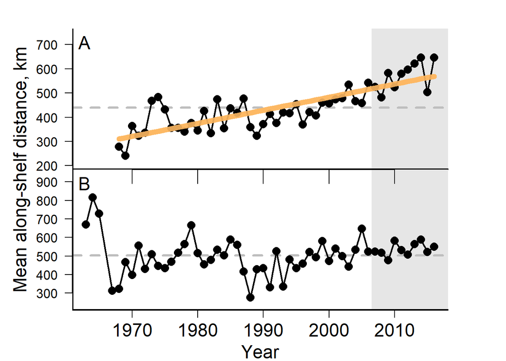

Black sea bass along-shelf distance trends in spring (A) and fall (B).

```r
# Relative working directories
data.dir  <- here::here('data')
r.dir <- here::here('R')

# Load data
load(file.path(data.dir,"SOE_data_erddap.Rdata"))

# Source plotting functions
source(file.path(r.dir,"BasePlot_source.R"))


opar <- par(mfrow = c(2, 1), mar = c(0, 0, 0, 0), oma = c(3.5, 5, 2, 4))

soe.plot(SOE.data, "Time", "black sea bass spring mean along-shelf dist",
         stacked = "A", rel.y.num = 1.1, suppressAxis = T,
         line.forward = T, tol = 0.15, x.start = 1963, end.start = 2007,
         cex.stacked = 1.5)
soe.plot(SOE.data, "Time", "black sea bass fall mean along-shelf dist",
         stacked = "B", rel.y.num = 1.1, tol = 0.15, end.start = 2007,
         cex.stacked = 1.5)
soe.stacked.axis("Year", "Mean along-shelf distance, km", y.line = 3.0)
```

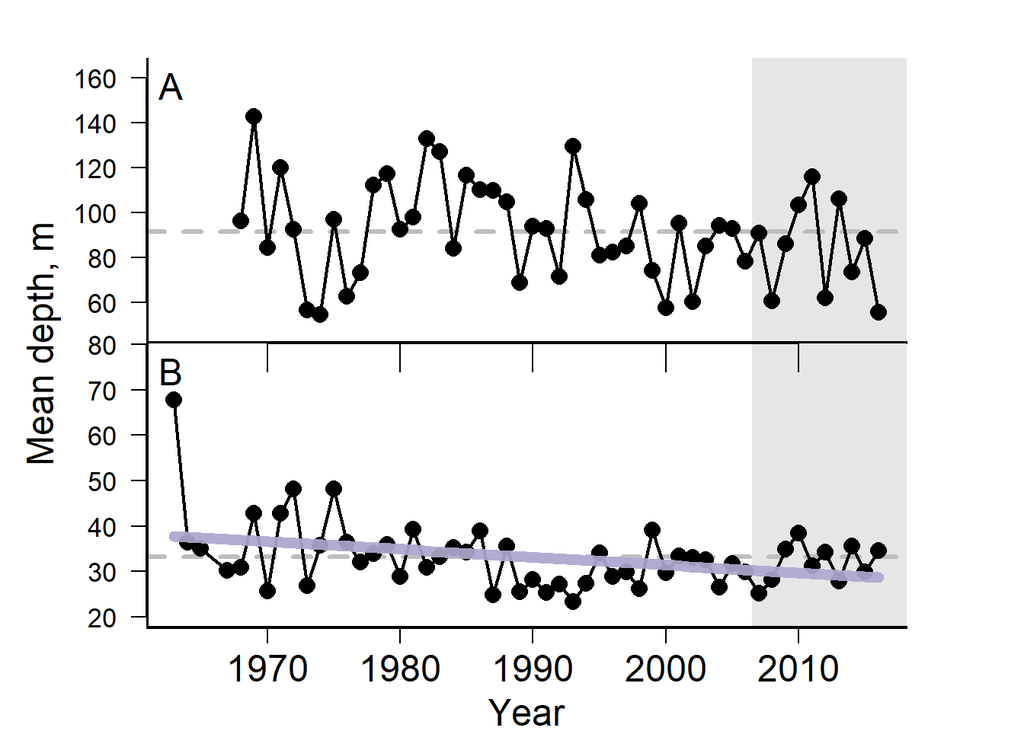

Mean depth of black sea bass in spring (A) and fall (B) on the Northeast Continental Shelf.

```r
opar <- par(mfrow = c(2, 1), mar = c(0, 0, 0, 0), oma = c(3.5, 5, 2, 4))

soe.plot(SOE.data, "Time", "black sea bass spring mean depth",
         stacked = "A", rel.y.num = 1.1, suppressAxis = T,
          tol = 0.15, x.start = 1963, end.start = 2007,
         cex.stacked = 1.5)
soe.plot(SOE.data, "Time", "black sea bass fall mean depth",
         stacked = "B", rel.y.num = 1.1, tol = 0.15, end.start = 2007,line.forward = T,
         cex.stacked = 1.5)
soe.stacked.axis("Year", "Mean depth, m", y.line = 3.0)
```